# Weibull on Pregnancy Intervals

### Interpretation

We see a significant relationship between both entanglement (negative) and good health (negative). How do we interpret these - especially health?

Let’s do a quick EDA to see the patterns:

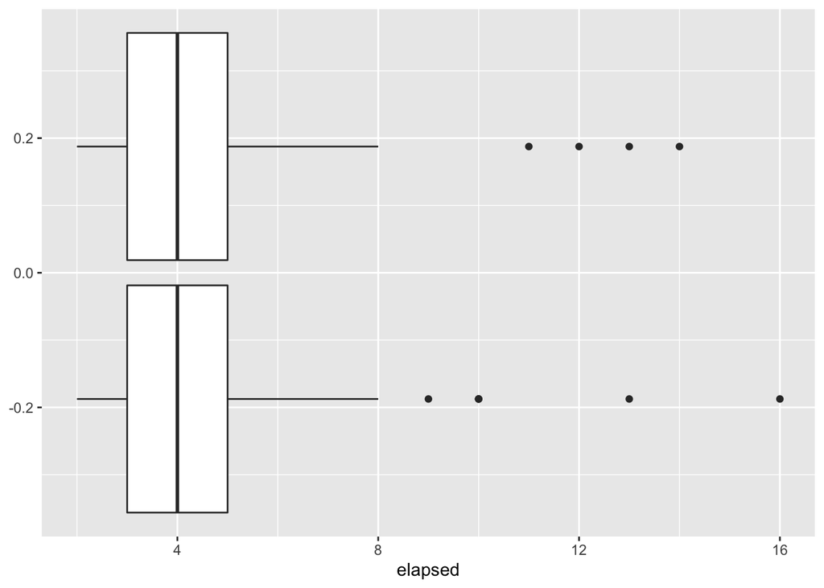

```r
library(ggplot2)
ggplot(data = xdat, aes(elapsed, group = factor(sev_fac)))+
  geom_boxplot()
```

While significant, the effect is not huge:

```r
xdat %>% group_by(sev_fac) %>% summarize(mean(elapsed))
```

```
## # A tibble: 2 x 2
##   sev_fac `mean(elapsed)`
##     <dbl>           <dbl>
## 1       0            4.27
## 2       1            4.55
```

Now about the health:

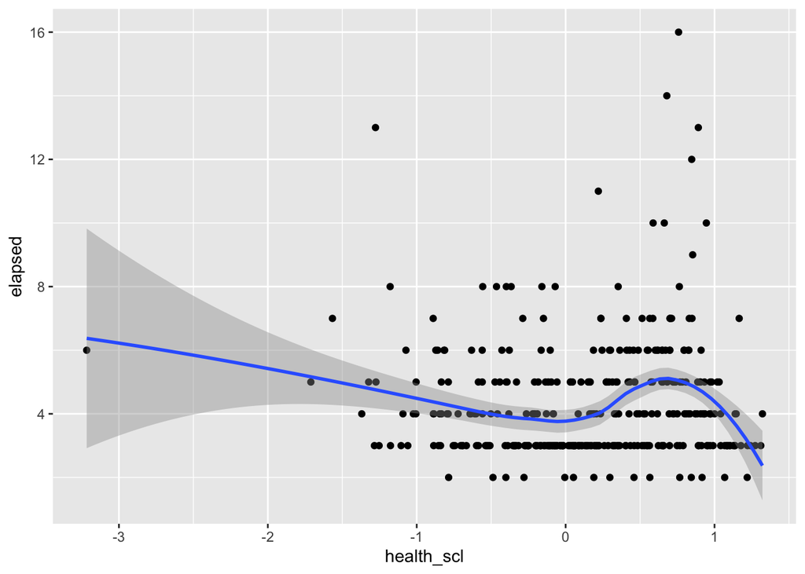

```r
ggplot(data = xdat, aes(health_scl, elapsed ))+
  geom_point()+
  geom_smooth()
```

This was not what I’d expected to see, and I’m wondering about the animals with 9 year + gaps. Like is there something fundamentally different about them, and/or if there’s a time factor in here too. I’m just going to pull those out to investigate:

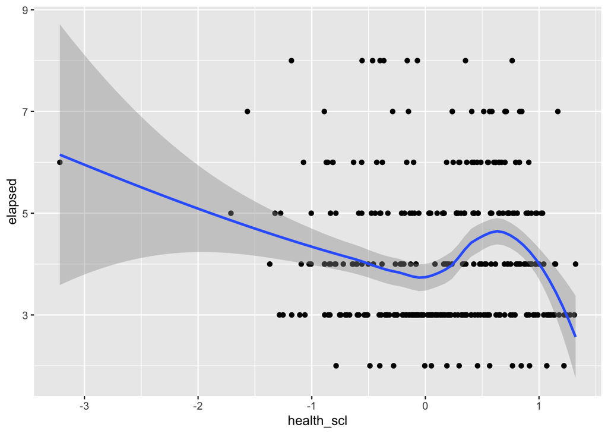

```r
ggplot(data = subset(xdat, elapsed < 9), aes(health_scl, elapsed ))+
  geom_point()+
  geom_smooth()
```

Let’s facet by decade just for exploration

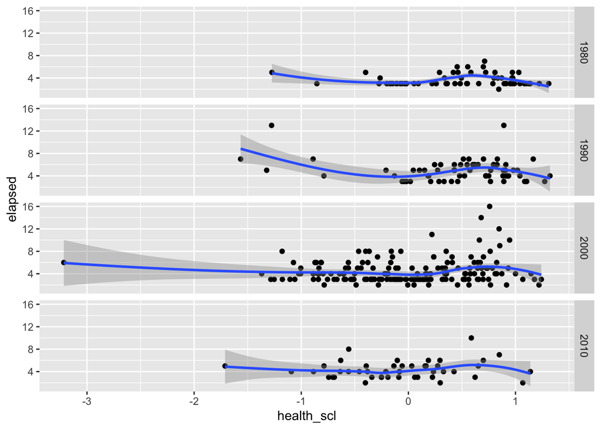

```r
ggplot(data = xdat, aes(health_scl, elapsed ))+
  geom_point()+
  geom_smooth()+
  facet_grid('decade')
```

So we have a number of whales in poor health with longer intervals in the 1990’s, but also a lot of whales in better health *still* with long intervals in the 2000’s. Though there’s also a mean shift by decade as well:

```r
xdat %>%
  group_by(decade) %>%
  summarize(median(health_scl))
```

```
## # A tibble: 4 x 2
##   decade `median(health_scl)`
##    <dbl>                <dbl>
## 1   1980               0.554
## 2   1990               0.574
## 3   2000               0.0525
## 4   2010              -0.0862
```